# Machine Learning Project FIFA Presentation

## Summary

- Présentation du contexte et des données
- Première classification (modèles et comparaison)
- Deuxième classification (modèles et comparaison)
- Conclusion

## Présentation du contexte

[figure not shown]

Les positions au football

- Certains jeunes joueurs peuvent jouer différents postes
- Objectif : conseiller le poste où il serait le meilleur (attaquant, milieu ou défenseur)

## Méthodologie

- Utilisation des données du jeu vidéo de football Fifa 21
- Utilisation de méthodes de machine learning : régression, svm, adaboost, arbre de décision et réseaux de neurones

## Présentation des données

```
##  [1] "Position"            "Crossing"            "Finishing"
##  [4] "Heading.Accuracy"    "Short.Passing"       "Volleys"
##  [7] "Dribbling"           "Curve"               "FK.Accuracy"
## [10] "Long.Passing"        "Ball.Control"        "Acceleration"
## [13] "Sprint.Speed"        "Agility"             "Reactions"
## [16] "Balance"             "Shot.Power"          "Jumping"
## [19] "Stamina"             "Strength"            "Long.Shots"
## [22] "Aggression"          "Interceptions"       "Positioning"
## [25] "Vision"              "Penalties"           "Composure"
## [28] "Defensive.Awareness" "Standing.Tackle"     "Sliding.Tackle"
```

## Présentation des données (att)

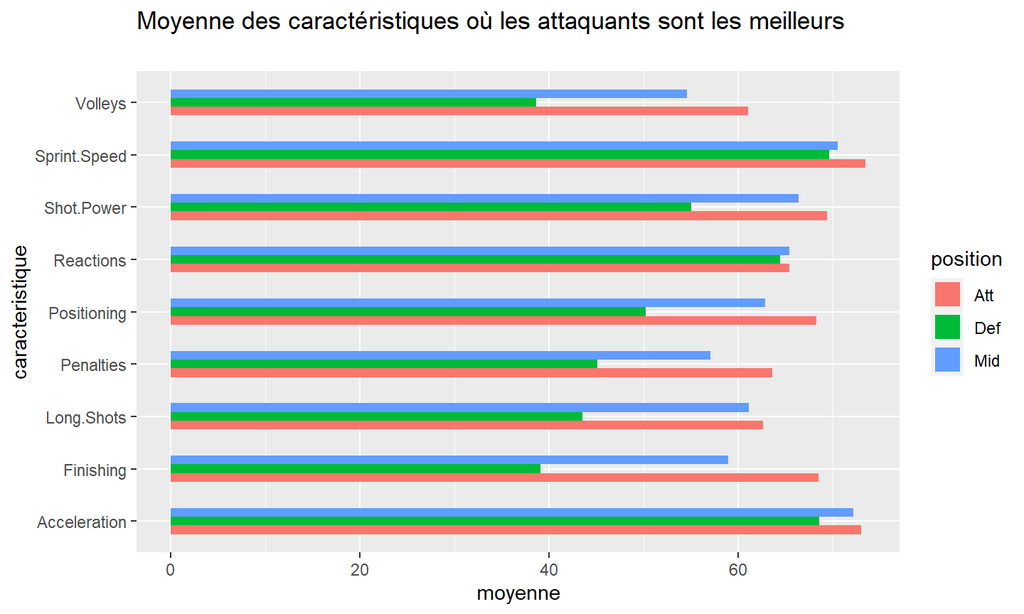

## Présentation des données (mid)

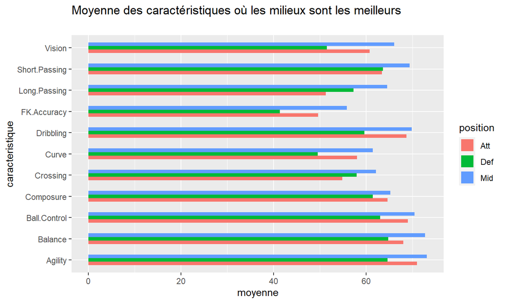

## Présentation des données (def)

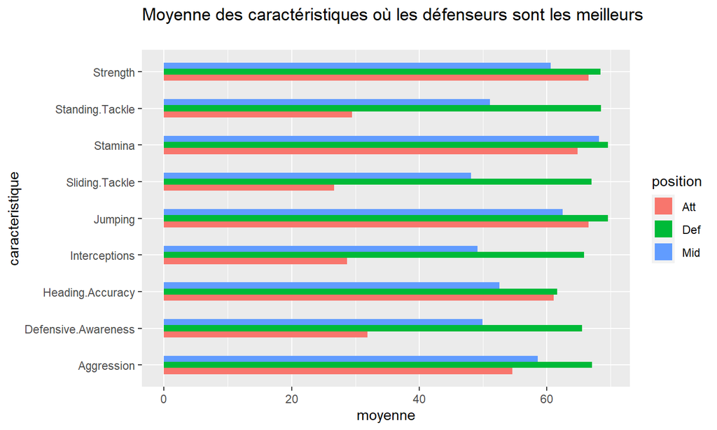

- Classification d’abord des attaquants et défenseurs, puis des attaquants défenseurs et milieux.

## Identification de variables corrélés

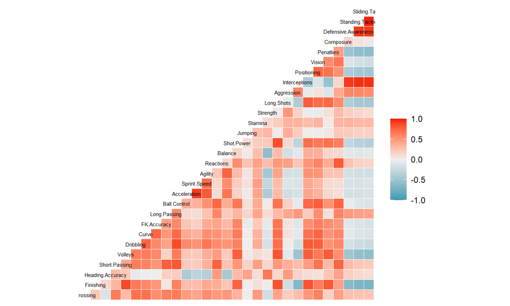

## Plots conditionnels

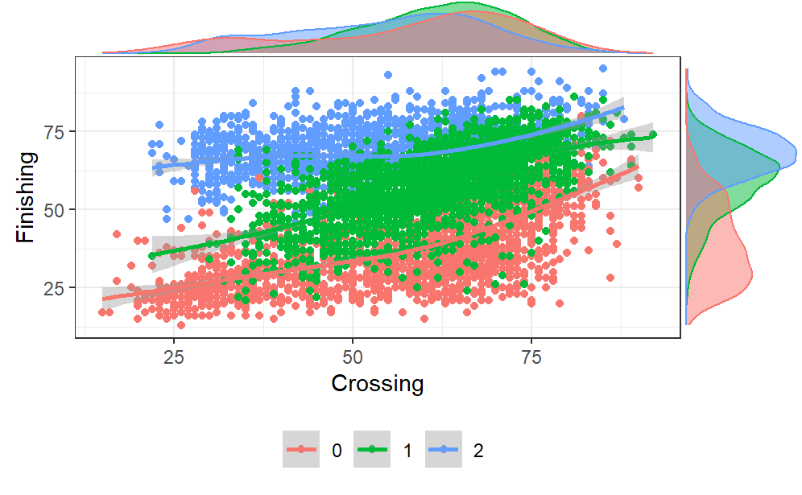

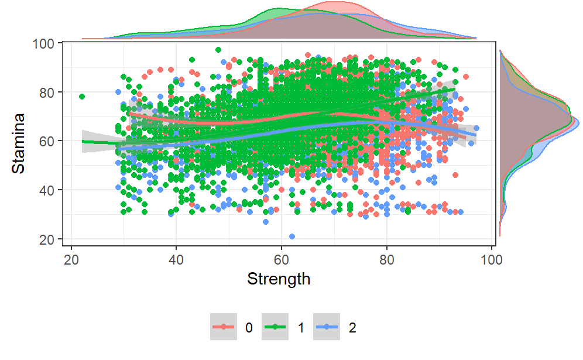

## Séparation de données

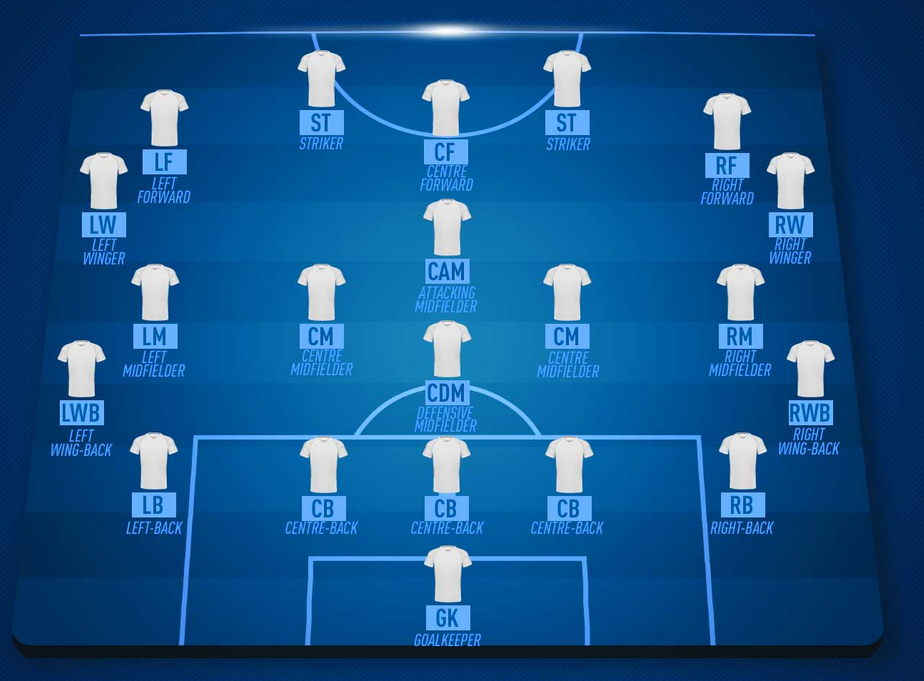

```r
Attack=c("LW", "LF", "RW","RF", "CF", "ST")
Defense=c("RB", "RWB", "LB", "LWB", "CB")
Midfielder=c("CAM", "CM", "CDM", "LM", "RM")
knitr::include_graphics("fifa_position.png")
```

## Regression logistique

[figure not shown]

```r
#modeleRegLog = glm(Position ~ ., data = train2, family = binomial)
#summary(modeleRegLog)
```

## Linear SVM

```
## Support Vector Machines with Linear Kernel
##
## 3050 samples
##   29 predictor
##    2 classes: 'A', 'D'
##
## No pre-processing
## Resampling: Cross-Validated (10 fold)
## Summary of sample sizes: 2746, 2745, 2746, 2746, 2744, 2745, ...
## Resampling results across tuning parameters:
##
##   C      Accuracy   Kappa
##   1e-03  0.9803363  0.9606623
##   1e-02  0.9859080  0.9717993
##   1e+00  0.9872195  0.9744122
##   1e+01  0.9865637  0.9731015
##   1e+02  0.9865637  0.9731015
##   1e+03  0.9868916  0.9737588
##
## Accuracy was used to select the optimal model using the largest value.
## The final value used for the model was C = 1.
```

## Accuracy of linear svm

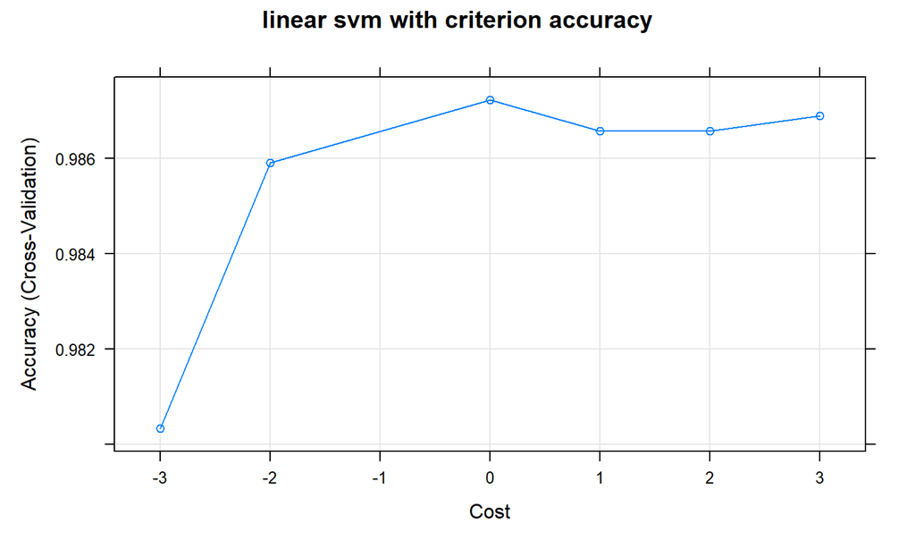

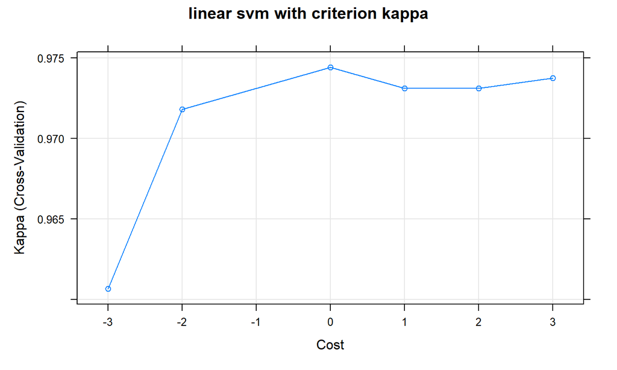

## Radial SVM

```
## Support Vector Machines with Radial Basis Function Kernel
##
## 3050 samples
##   29 predictor
##    2 classes: 'A', 'D'
##
## No pre-processing
## Resampling: Cross-Validated (10 fold)
## Summary of sample sizes: 2746, 2745, 2745, 2745, 2745, 2745, ...
## Resampling results across tuning parameters:
##
##   C      sigma  Accuracy   Kappa
##   1e-03  0.1    0.5167213  0.000000000
##   1e-03  0.5    0.5167213  0.000000000
##   1e-03  1.0    0.5167213  0.000000000
##   1e-03  2.0    0.5167213  0.000000000
##   1e-03  3.0    0.5167213  0.000000000
##   1e-03  4.0    0.5167213  0.000000000
##   1e-02  0.1    0.9711507  0.942188678
##   1e-02  0.5    0.5167213  0.000000000
##   1e-02  1.0    0.5167213  0.000000000
##   1e-02  2.0    0.5167213  0.000000000
##   1e-02  3.0    0.5167213  0.000000000
##   1e-02  4.0    0.5167213  0.000000000
##   1e+00  0.1    0.9878688  0.975717127
##   1e+00  0.5    0.9141175  0.827144850
##   1e+00  1.0    0.6229597  0.225558249
##   1e+00  2.0    0.5180318  0.002802345
##   1e+00  3.0    0.5180318  0.002802345
##   1e+00  4.0    0.5180318  0.002802345
##   1e+01  0.1    0.9865573  0.973092654
##   1e+01  0.5    0.9177209  0.834430465
##   1e+01  1.0    0.6586986  0.300684701
##   1e+01  2.0    0.5180318  0.002802345
##   1e+01  3.0    0.5180318  0.002802345
##   1e+01  4.0    0.5180318  0.002802345
##   1e+02  0.1    0.9865573  0.973092654
##   1e+02  0.5    0.9177209  0.834430465
##   1e+02  1.0    0.6586986  0.300684701
##   1e+02  2.0    0.5180318  0.002802345
##   1e+02  3.0    0.5180318  0.002802345
##   1e+02  4.0    0.5180318  0.002802345
##   1e+03  0.1    0.9865573  0.973092654
##   1e+03  0.5    0.9177209  0.834430465
##   1e+03  1.0    0.6586986  0.300684701
##   1e+03  2.0    0.5180318  0.002802345
##   1e+03  3.0    0.5180318  0.002802345
##   1e+03  4.0    0.5180318  0.002802345
##
## Accuracy was used to select the optimal model using the largest value.
## The final values used for the model were sigma = 0.1 and C = 1.
```

## Accuracy of radial svm

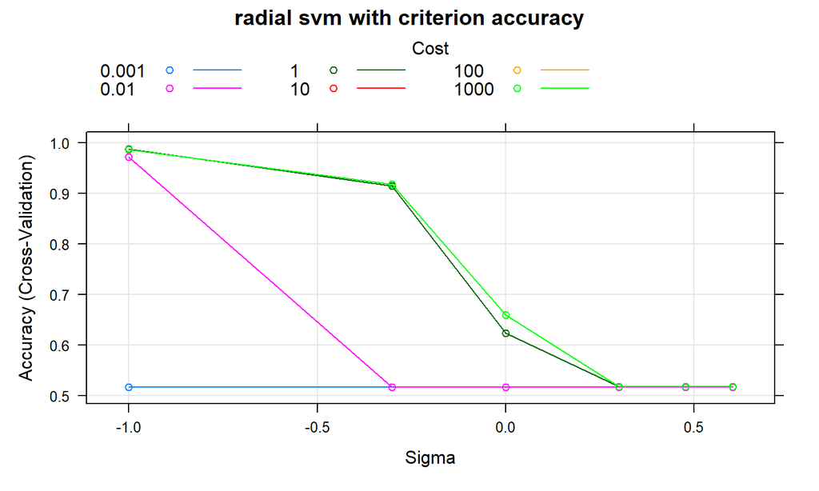

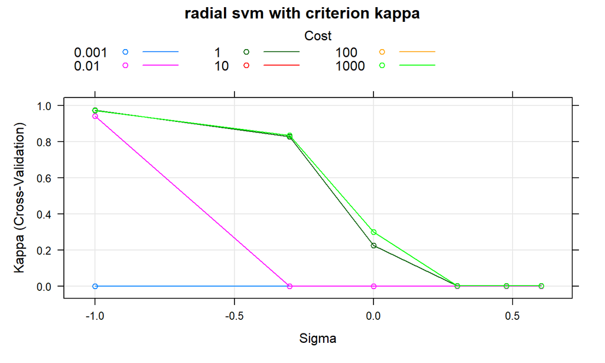

## Prédiction of linear svm

```
## Confusion Matrix and Statistics
##
##           Reference
## Prediction   A   D
##          A 533   4
##          D   6 475
##
##                Accuracy : 0.9902
##                  95% CI : (0.982, 0.9953)
##     No Information Rate : 0.5295
##     P-Value [Acc > NIR] : <2e-16
##
##                   Kappa : 0.9803
##
##  Mcnemar's Test P-Value : 0.7518
##
##             Sensitivity : 0.9889
##             Specificity : 0.9916
##          Pos Pred Value : 0.9926
##          Neg Pred Value : 0.9875
##              Prevalence : 0.5295
##          Detection Rate : 0.5236
##    Detection Prevalence : 0.5275
##       Balanced Accuracy : 0.9903
##
##        'Positive' Class : A
##
```

## Arbre de décision

```
## CART
##
## 3050 samples
##   29 predictor
##    2 classes: 'A', 'D'
##
## No pre-processing
## Resampling: Cross-Validated (10 fold)
## Summary of sample sizes: 2745, 2745, 2744, 2746, 2745, 2745, ...
## Resampling results across tuning parameters:
##
##   cp     Accuracy   Kappa
##   1e-05  0.9763815  0.9527097
##   1e-04  0.9763815  0.9527097
##   1e-03  0.9790098  0.9579845
##   1e-02  0.9773694  0.9547086
##   1e-01  0.9501616  0.9003331
##   1e+00  0.5167214  0.0000000
##
## Accuracy was used to select the optimal model using the largest value.
## The final value used for the model was cp = 0.001.
```

## Précision d’arbre de décision

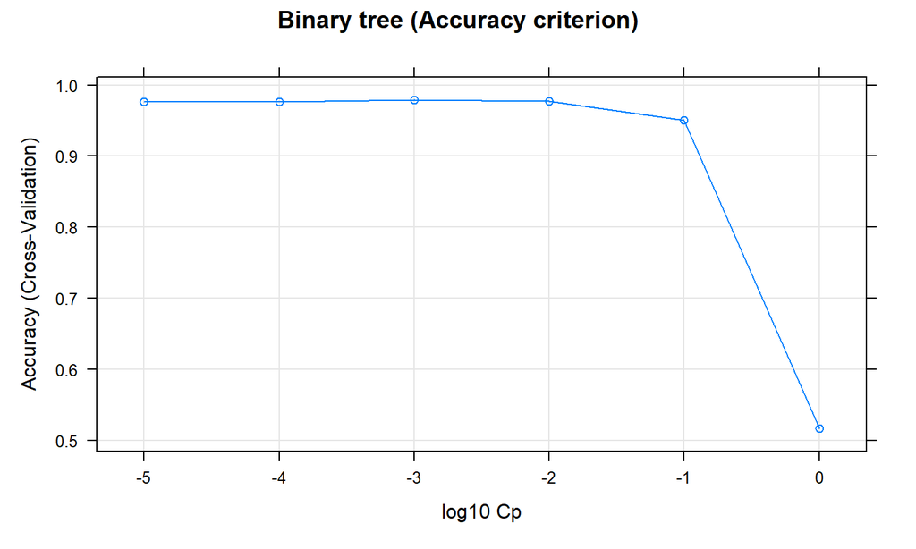

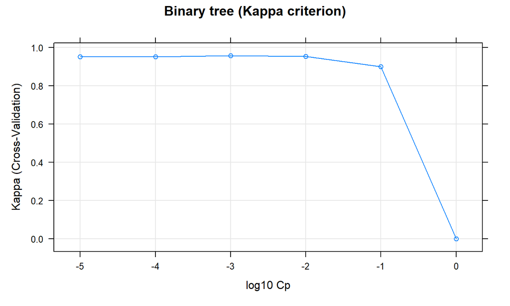

## Prédicion d’arbre de décision

```
## Confusion Matrix and Statistics
##
##           Reference
## Prediction   A   D
##          A 524   5
##          D  15 474
##
##                Accuracy : 0.9804
##                  95% CI : (0.9698, 0.988)
##     No Information Rate : 0.5295
##     P-Value [Acc > NIR] : < 2e-16
##
##                   Kappa : 0.9606
##
##  Mcnemar's Test P-Value : 0.04417
##
##             Sensitivity : 0.9722
##             Specificity : 0.9896
##          Pos Pred Value : 0.9905
##          Neg Pred Value : 0.9693
##              Prevalence : 0.5295
##          Detection Rate : 0.5147
##    Detection Prevalence : 0.5196
##       Balanced Accuracy : 0.9809
##
##        'Positive' Class : A
##
```

## The best tree

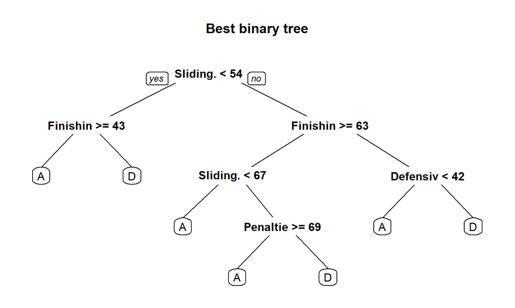

## Pourquoi l’arbre de décision n’est pas coûteux en temps de calcul ?

- Les algorithmes d’arbres de décision ne calculent pas tous les arbres possibles lorsqu’ils ajustent un arbre.
- Les algorithmes d’ajustement des arbres de décision prennent généralement des décisions avides au cours du processus d’ajustement.
- Plus on s’enfonce dans l’arbre de décision, plus l’ensemble des données qui ont atteint le noeud donné est réduit, un sous-ensemble de données plus petit.

## Ada boost

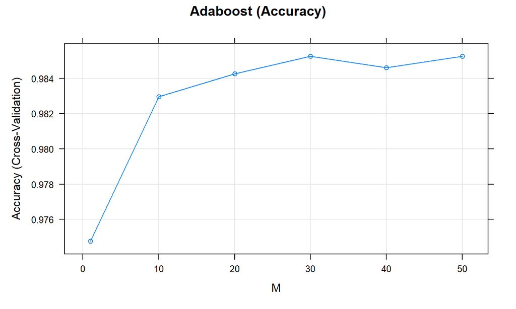

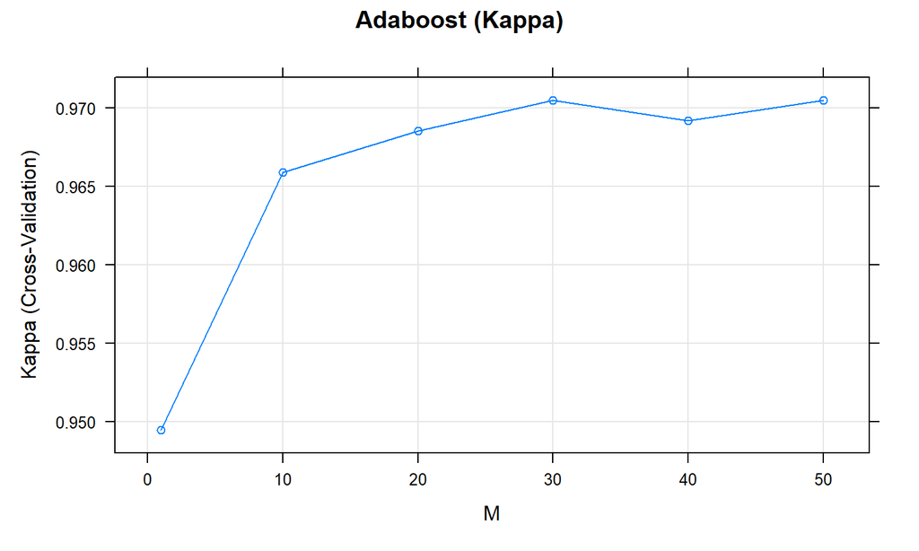

## Prédicition

```
          Accuracy : 0.9941
             95% CI : (0.9872, 0.9978)
No Information Rate : 0.5295
P-Value [Acc > NIR] : <2e-16
```

## Neural network

## single layer

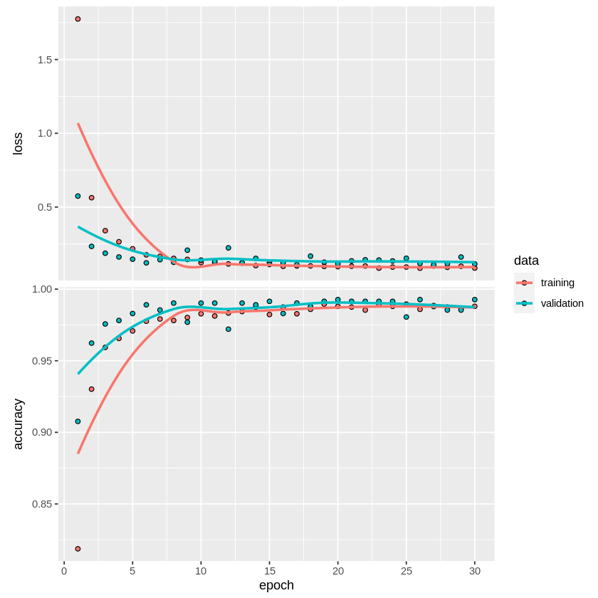

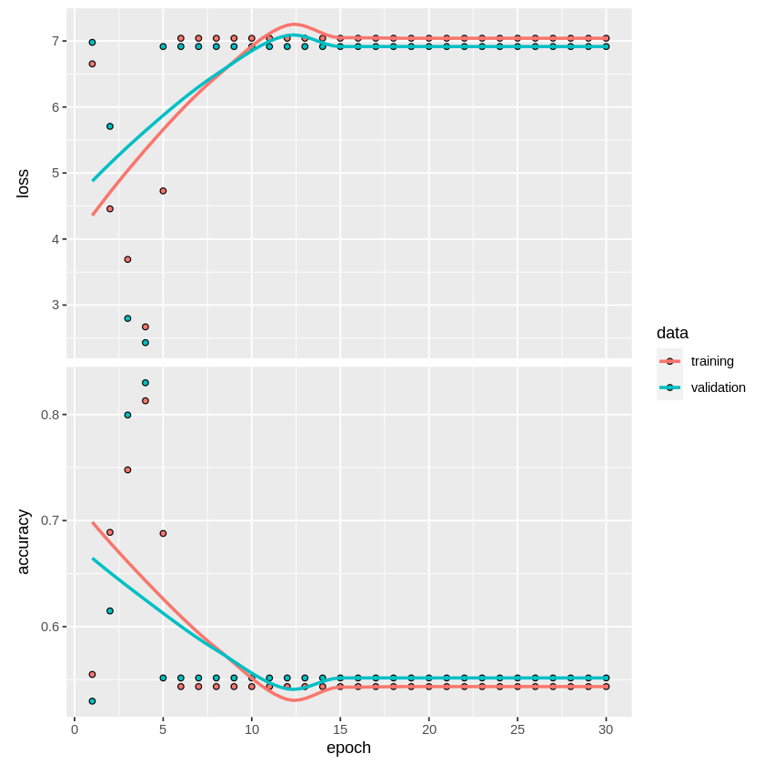

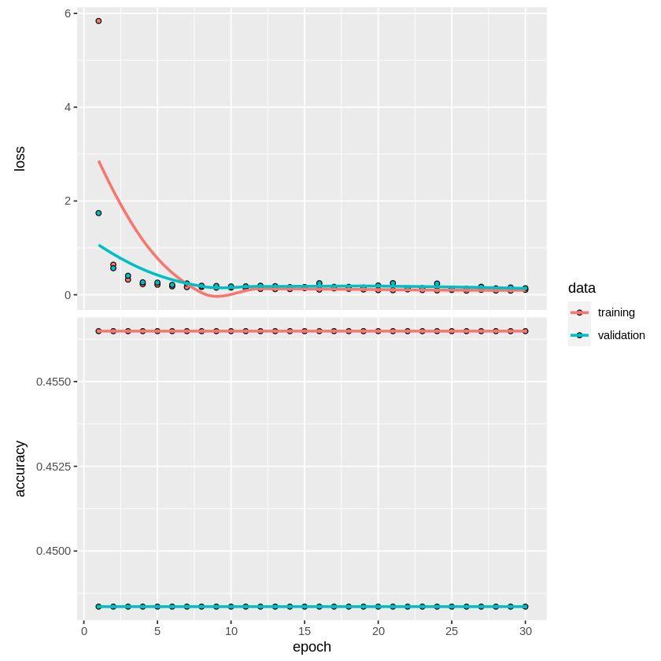

Neural netwwork single layer

## two layers

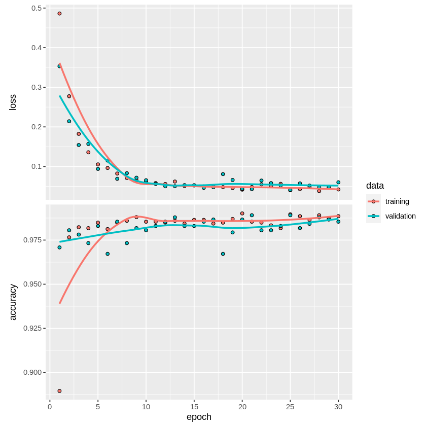

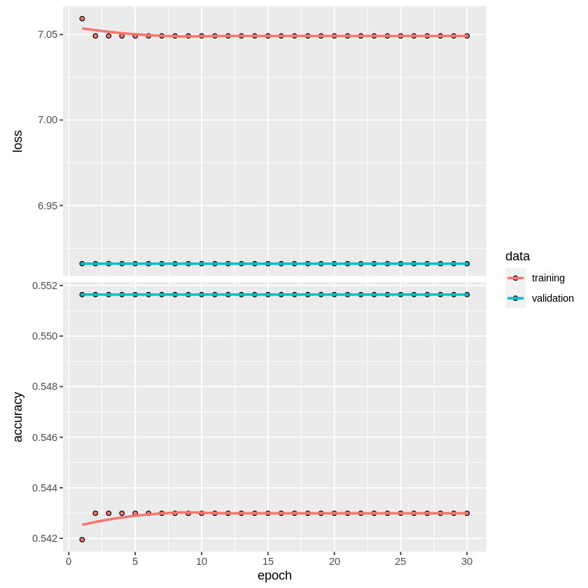

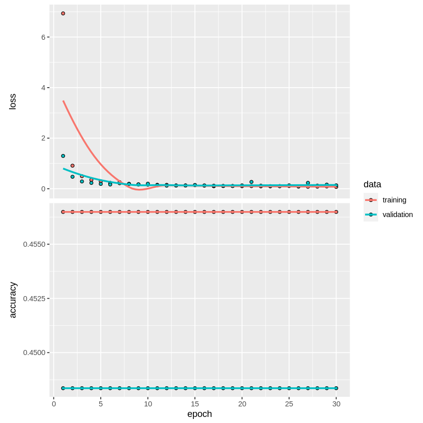

Neural netwwork two layer

## Comparaison (att & def)

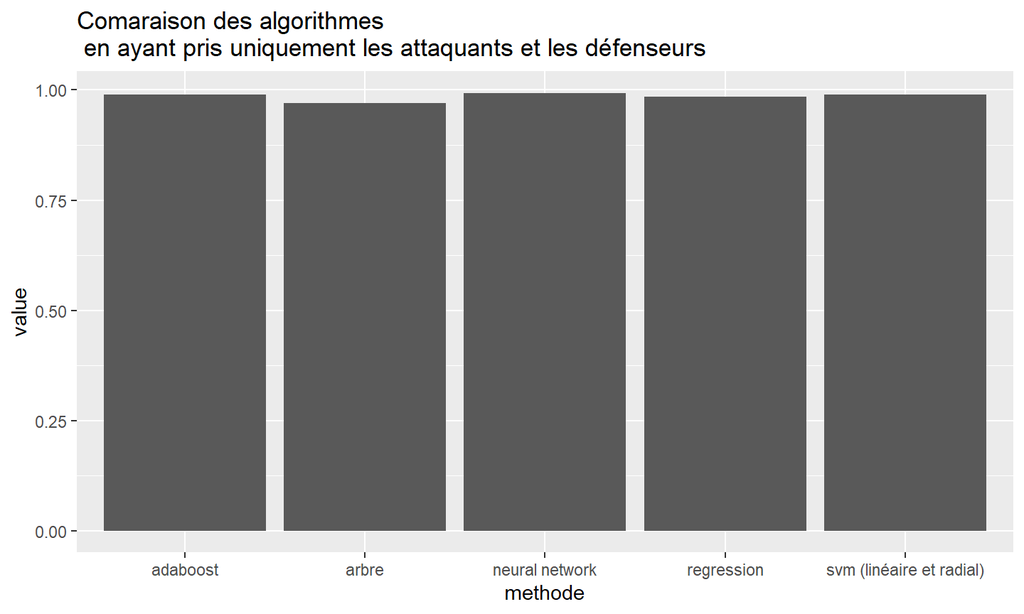

## Prise en compte des milieux de terrain

Nous considérons les postes de milieux.

## Regression Logistique

Nous utilisons la même manière précédente:

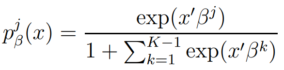

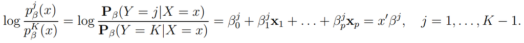

## Regression Logistique

Prediction finale:

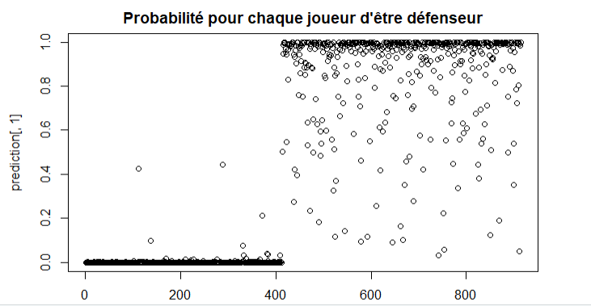

## SVM

```
## Support Vector Machines with Polynomial Kernel
##
## 4893 samples
##   29 predictor
##    3 classes: 'A', 'D', 'M'
##
## No pre-processing
## Resampling: Cross-Validated (10 fold)
## Summary of sample sizes: 4404, 4404, 4403, 4404, 4403, 4404, ...
## Resampling results across tuning parameters:
##
##   C      degree  Accuracy   Kappa
##   1e-04  2       0.8246572  0.7159073
##   1e-04  3       0.8551041  0.7698037
##   1e-04  4       0.8256688  0.7263089
##   1e-04  5       0.8146325  0.7107062
##   1e-03  2       0.8559217  0.7709427
##   1e-03  3       0.8508071  0.7654431
##   1e-03  4       0.8125900  0.7074951
##   1e-03  5       0.8138137  0.7094845
##   1e-02  2       0.8610263  0.7804103
##   1e-02  3       0.8193364  0.7179904
##   1e-02  4       0.8144284  0.7103662
##   1e-02  5       0.8138137  0.7094845
##   1e-01  2       0.8422244  0.7524300
##   1e-01  3       0.8189237  0.7180436
##   1e-01  4       0.8144284  0.7103662
##   1e-01  5       0.8138137  0.7094845
##   1e+00  2       0.8138141  0.7092196
##   1e+00  3       0.8189237  0.7180436
##   1e+00  4       0.8144284  0.7103662
##   1e+00  5       0.8138137  0.7094845
##
## Tuning parameter 'scale' was held constant at a value of 1
## Accuracy was used to select the optimal model using the largest value.
## The final values used for the model were degree = 2, scale = 1 and C = 0.01.
```

## Accuracy and quality of polynomial svm

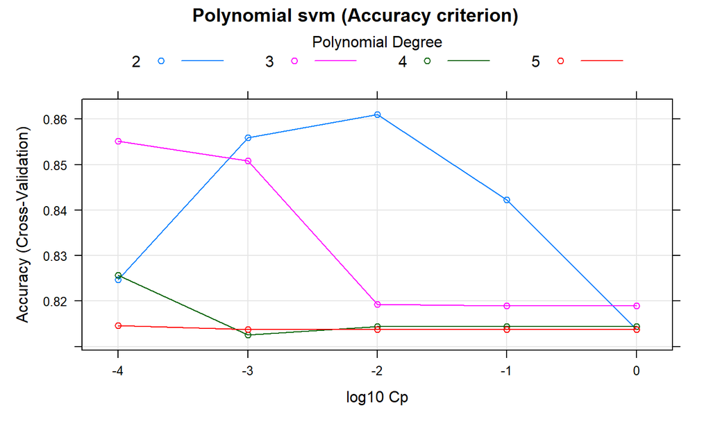

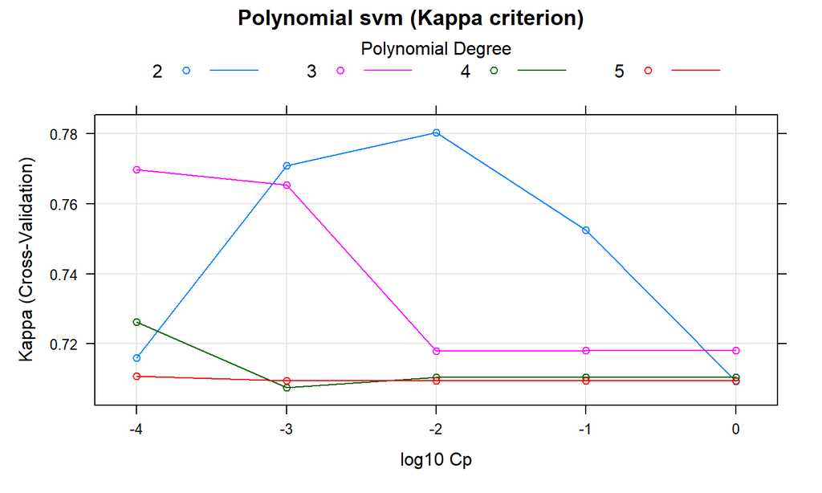